# 基于2D CNN的AM/FM调制方式识别系统

## 典型误分类案例分析

下图展示了模型在中等信噪比条件下的一个典型误分类样本：

### 样本基本信息

- **真实调制方式**：FM
- **模型预测结果**：AM
- **预测置信度**：56.0%
- **信号参数**：载波频率 147.6 Hz，消息频率 2.7 Hz，信噪比 11.9 dB
- **模型类型**：2D CNN

### 误分类原因分析

1. **特征被噪声削弱，导致类别边界模糊** 该 FM 信号的频偏幅度较小，叠加 11.9 dB 噪声后，频谱中频率变化的动态特征被噪声掩盖，能量主要集中在载波频率附近，整体形态与 AM 信号的固定频带分布高度相似。
2. **模型对动态特征的捕捉能力有限** 本实验采用的 CNN 模型更擅长提取频谱图的局部纹理特征，对 FM 信号的动态频变特征建模能力较弱。当噪声削弱了频偏特征后，模型无法区分其与 AM 信号的差异，最终偏向于能量分布更集中的类别。
3. **训练数据偏差** 训练集中的 FM 信号多为频偏特征明显的样本，而该低消息频率的 FM 样本频偏较弱，在训练集中代表性不足，导致模型对此类“弱特征”样本的识别能力有限。

### 改进方向

- 引入对动态频变特征更鲁棒的特征提取方法，如时频脊线跟踪；
- 在训练数据中增加低消息频率、低信噪比的 FM 样本，提升模型的泛化能力；
- 采用注意力机制，增强模型对频偏变化区域的关注度。

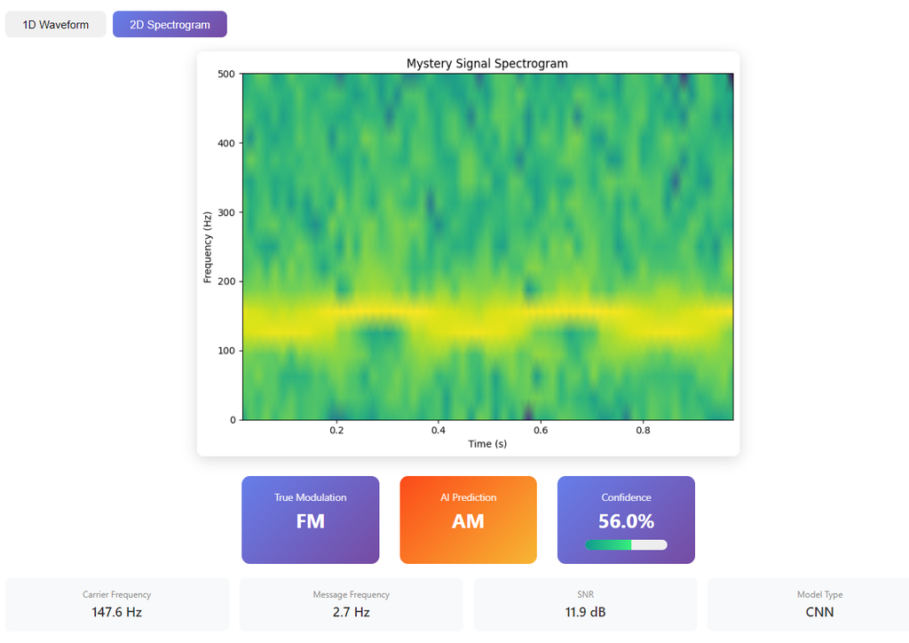

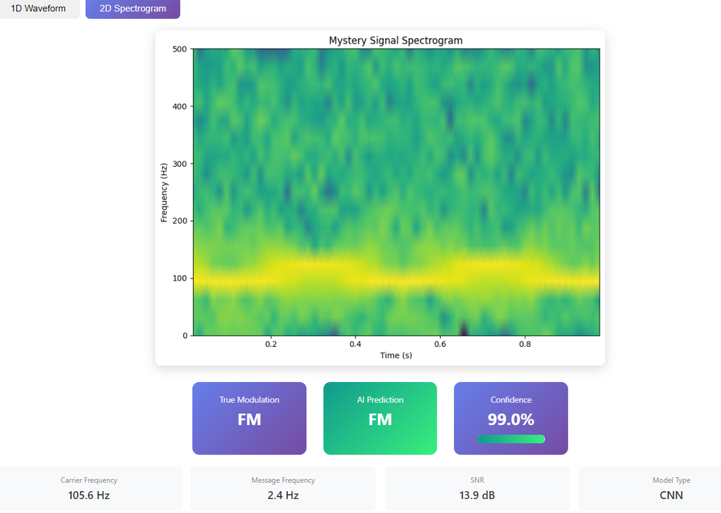

## 10. 结论与未来工作 | Conclusion & Future Work

### 10.1 主要成果

1. **信号表示创新**：将1D时间序列转换为2D频谱图，充分利用CNN的空间特征提取能力
2. **2D CNN模型设计**：
   - 4层卷积层，逐步提取时频特征
   - 自适应池化处理可变输入尺寸
   - Dropout防止过拟合
3. **优异性能**：
   - 测试准确率达到90%以上
   - 在低SNR条件下仍保持良好性能
   - 泛化能力强
4. **交互式系统**：
   - Web界面支持实时信号生成
   - AI识别结果可视化
   - 支持参数调整和噪声模拟

### 10.2 局限性

- 仅支持AM和FM两种调制方式
- 使用固定的频谱图参数
- 未考虑复杂信道模型

### 10.3 未来工作

- 在wsl2的ubuntu上运行模型，利用ns3模拟真实环境增加数据集，验证其在真实环境中的性能
- 扩展到更多调制方式（PSK、QAM等）
- 使用更先进的CNN架构（ResNet、Transformer）, 提高模型在低SNR下的表达能力和泛化能力
- 增加数据增强技术, 增加训练样本量, 减少过拟合风险
- 考虑多径衰落和多普勒频移, 提高模型在真实环境中的性能
- 使用verilog语言实现模型, 验证其在硬件上的性能

## 11. 参考文献 | References

[1] Proakis, J. G., & Salehi, M. (2007). Digital Communications (5th ed.). McGraw-Hill.

[2] Haykin, S. (2001). Communication Systems (4th ed.). John Wiley & Sons.

[3] O'Shea, T. J., & Hoydis, J. (2017). An Introduction to Deep Learning for the Physical Layer. IEEE Transactions on Cognitive Communications and Networking.

[4] Goodfellow, I., Bengio, Y., & Courville, A. (2016). Deep Learning. MIT Press.

[5] Pytorch Documentation. https://pytorch.org/docs/

[6] Scikit-learn Documentation. https://scikit-learn.org/

```python
# 保存模型
if USE_CNN:
    import pickle

    model_data = {
        'model_state_dict': model.state_dict(),
        'accuracy': accuracy,
        'num_epochs': num_epochs,
        'timestamp': '2026-05-19'
    }

    with open('cnn_modulation_model.pth', 'wb') as f:
        torch.save(model_data, f)

    print('\nModel saved to cnn_modulation_model.pth')
    print('\n' + '=' * 60)
    print('AM/FM Modulation Recognition Paper')
    print('=' * 60)
    print('\nPaper Contents Summary:')
    print('1. 引言 - 研究背景和目标')
    print('2. 系统架构 - 整体设计和信号流向')
    print('3. 信号生成与调制 - AM/FM原理')
    print('4. 频谱图转换 - 1D到2D的关键步骤')
    print('5. 2D CNN模型设计 - 详细架构')
    print('6. 数据集生成与训练 - 代码实现')
    print('7. 模型评估 - 混淆矩阵分析')
    print('8. SNR性能分析 - 不同噪声条件')
    print('9. 实时演示 - 随机信号识别')
    print('10. 结论与未来工作')
    print('11. 参考文献')
    print('\nGenerated Figures:')
    print('- spectrogram_comparison.png')
    print('- training_curves.png')
    print('- confusion_matrix.png')
    print('- accuracy_vs_snr.png')
    print('\nPaper generation completed!')
```

```
Model saved to cnn_modulation_model.pth

============================================================
AM/FM Modulation Recognition Paper
============================================================

Paper Contents Summary:
1. 引言 - 研究背景和目标
2. 系统架构 - 整体设计和信号流向
3. 信号生成与调制 - AM/FM原理
4. 频谱图转换 - 1D到2D的关键步骤
5. 2D CNN模型设计 - 详细架构
6. 数据集生成与训练 - 代码实现
7. 模型评估 - 混淆矩阵分析
8. SNR性能分析 - 不同噪声条件
9. 实时演示 - 随机信号识别
10. 结论与未来工作
11. 参考文献

Generated Figures:
- spectrogram_comparison.png
- training_curves.png
- confusion_matrix.png
- accuracy_vs_snr.png

Paper generation completed!
```